# Data608 Project 1

Vikas Sinha

September 8, 2018

**Principles of Data Visualization and Introduction to ggplot2**

Read in data regarding the 5,000 fastest growing companies in the US, as compiled by Inc. magazine:

```r
library(ggplot2)
library(tidyr)
library(dplyr)
library(scales)


inc <- read.csv(url("https://raw.githubusercontent.com/vsinha-cuny/data608/master/proj1/inc5000_data.csv"))
```

Preview this data:

```r
head(inc)
```

```
##   Rank                         Name Growth_Rate   Revenue
## 1    1                         Fuhu      421.48 1.179e+08
## 2    2        FederalConference.com      248.31 4.960e+07
## 3    3                The HCI Group      245.45 2.550e+07
## 4    4                      Bridger      233.08 1.900e+09
## 5    5                       DataXu      213.37 8.700e+07
## 6    6 MileStone Community Builders      179.38 4.570e+07
##                       Industry Employees         City State
## 1 Consumer Products & Services       104   El Segundo    CA
## 2          Government Services        51     Dumfries    VA
## 3                       Health       132 Jacksonville    FL
## 4                       Energy        50      Addison    TX
## 5      Advertising & Marketing       220       Boston    MA
## 6                  Real Estate        63       Austin    TX
```

```r
summary(inc)
```

```
##       Rank                                     Name       Growth_Rate
##  Min.   :   1   110 Consulting                   :   1   Min.   :  0.340
##  1st Qu.:1252   11thStreetCoffee.com             :   1   1st Qu.:  0.770
##  Median :2502   123 Exteriors                    :   1   Median :  1.420
##  Mean   :2502   1st American Systems and Services:   1   Mean   :  4.612
##  3rd Qu.:3751   1st Equity                       :   1   3rd Qu.:  3.290
##  Max.   :5000   1-Stop Translation USA           :   1   Max.   :421.480
##                 (Other)                          :4995
##     Revenue                                  Industry      Employees
##  Min.   :2.000e+06   IT Services                 : 733   Min.   :    1.0
##  1st Qu.:5.100e+06   Business Products & Services: 482   1st Qu.:   25.0
##  Median :1.090e+07   Advertising & Marketing     : 471   Median :   53.0
##  Mean   :4.822e+07   Health                      : 355   Mean   :  232.7
##  3rd Qu.:2.860e+07   Software                    : 342   3rd Qu.:  132.0
##  Max.   :1.010e+10   Financial Services          : 260   Max.   :66803.0
##                      (Other)                     :2358   NA's   :12
##             City          State
##  New York     : 160   CA     : 701
##  Chicago      :  90   TX     : 387
##  Austin       :  88   NY     : 311
##  Houston      :  76   VA     : 283
##  San Francisco:  75   FL     : 282
##  Atlanta      :  74   IL     : 273
##  (Other)      :4438   (Other):2764
```

Think a bit on what these summaries mean. Use the space below to add some more relevant non-visual exploratory information you think helps you understand this data:

```r
library(Hmisc)

describe(inc)
```

```
## inc
##
##  8  Variables      5001  Observations
## ---------------------------------------------------------------------------
## Rank
##        n  missing distinct     Info     Mean      Gmd      .05      .10
##     5001        0     4999        1     2502     1667      252      502
##      .25      .50      .75      .90      .95
##     1252     2502     3751     4501     4751
##
## lowest :    1    2    3    4    5, highest: 4996 4997 4998 4999 5000
## ---------------------------------------------------------------------------
## Name
##        n  missing distinct
##     5001        0     5001
##
## lowest : 110 Consulting                         11thStreetCoffee.com                   123 Exteriors                          1st American Systems and Services      1st Equity
## highest: Zoup!                                  ZT Wealth and Altus Group of Companies Zumasys                                Zurple                                 ZweigWhite
## ---------------------------------------------------------------------------
## Growth_Rate
##        n  missing distinct     Info     Mean      Gmd      .05      .10
##     5001        0     1147        1    4.612    6.493     0.43     0.50
##      .25      .50      .75      .90      .95
##     0.77     1.42     3.29     9.12    17.16
##
## lowest :   0.34   0.35   0.36   0.37   0.38, highest: 213.37 233.08 245.45 248.31 421.48
## ---------------------------------------------------------------------------
## Revenue
##         n   missing  distinct      Info      Mean       Gmd       .05
##      5001         0      1069         1  48222535  75111227   2400000
##       .10       .25       .50       .75       .90       .95
##   3000000   5100000  10900000  28600000  76900000 155600000
##
## lowest : 2.00e+06 2.10e+06 2.20e+06 2.30e+06 2.40e+06
## highest: 3.80e+09 4.50e+09 4.60e+09 4.70e+09 1.01e+10
## ---------------------------------------------------------------------------
## Industry
##        n  missing distinct
##     5001        0       25
##
```

[output cut: 9 more lines]

```
## lowest :     1     2     3     4     5, highest: 17057 18887 20000 32000 66803
## ---------------------------------------------------------------------------
## City
##        n  missing distinct
##     5001        0     1519
##
## lowest : Acton        Addison      Adrian       Agoura Hills Aiea
## highest: Worthington  Wyomissing   Yonkers      Youngsville  Zumbrota
## ---------------------------------------------------------------------------
## State
##        n  missing distinct
##     5001        0       52
##
## lowest : AK AL AR AZ CA, highest: VT WA WI WV WY
## ---------------------------------------------------------------------------
```

```r
detach(package:Hmisc)
```

## Question 1

Create a graph that shows the distribution of companies in the dataset by State (i.e. how many are in each state). There are a lot of States, so consider which axis you should use. This visualization is ultimately going to be consumed on a ‘portrait’ oriented screen (i.e. taller than wide), which should further guide your layout choices.

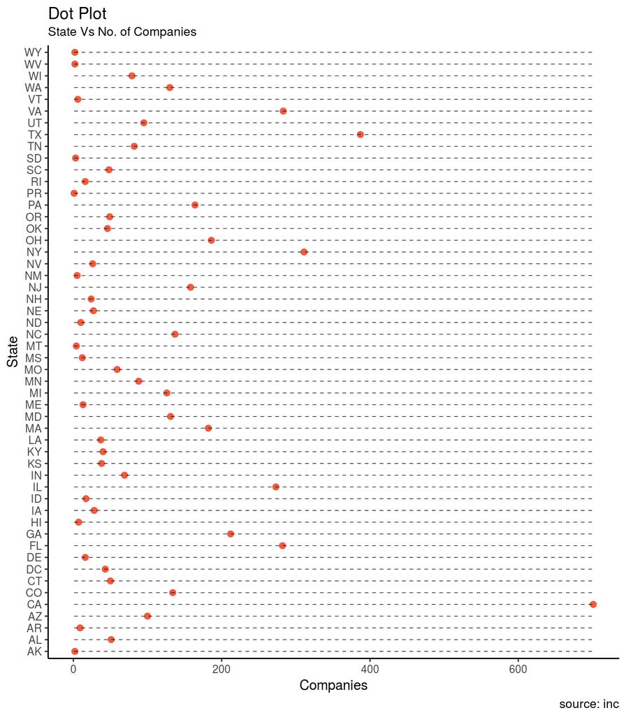

```r
# Reference: http://r-statistics.co/Top50-Ggplot2-Visualizations-MasterList-R-Code.html#Dot%20Plot


library(ggplot2)
library(scales)


states = data.frame(group_by_(inc, "State") %>% summarise(n()), stringsAsFactors = F)
names(states) = c("State", "Companies")
states = states[order(states$Companies, decreasing=T),]


# Plot
theme_set(theme_classic())
ggplot(states, aes(x=Companies, y=State)) +
  geom_point(col="tomato2", size=2) +   # Draw points
  geom_segment(aes(x=min(Companies),
                   xend=max(Companies),
                   y=State,
                   yend=State),
               linetype="dashed",
               size=0.2) +   # Draw dashed lines
  labs(title="Dot Plot",
       subtitle="State Vs No. of Companies",
       caption="source: inc")
```

## Question 2

Lets dig in on the state with the 3rd most companies in the data set. Imagine you work for the state and are interested in how many people are employed by companies in different industries. Create a plot that shows the average and/or median employment by industry for companies in this state (only use cases with full data, use R’s `complete.cases()` function.) In addition to this, your graph should show how variable the ranges are, and you should deal with outliers.

```r
# Select the state with the 3rd most companies in the data set.
sel3 = states[3,]
sel_state = as.character(sel3["State"][1,])
print(sel_state)
```

```
## [1] "NY"
```

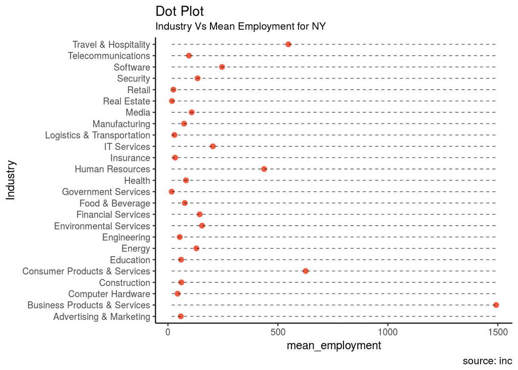

```r
state3 = inc %>% filter(State == sel_state)
state3 = state3[complete.cases(state3),]

industry3 = state3 %>% select(Employees, Industry)
industry3 = industry3 %>% group_by(Industry) %>% summarize(mean_employment=mean(Employees))
industry3 = industry3[order(industry3$mean_employment, decreasing = T),]

# Plot
theme_set(theme_classic())
ggplot(industry3, aes(x=mean_employment, y=Industry)) +
  geom_point(col="tomato2", size=2) +   # Draw points
  geom_segment(aes(x=min(mean_employment),
                   xend=max(mean_employment),
                   y=Industry,
                   yend=Industry),
               linetype="dashed",
               size=0.2) +   # Draw dashed lines
  labs(title="Dot Plot",
       subtitle="Industry Vs Mean Employment for NY",
       caption="source: inc")
```

## Question 3

Now imagine you work for an investor and want to see which industries generate the most revenue per employee. Create a chart that makes this information clear. Once again, the distribution per industry should be shown.

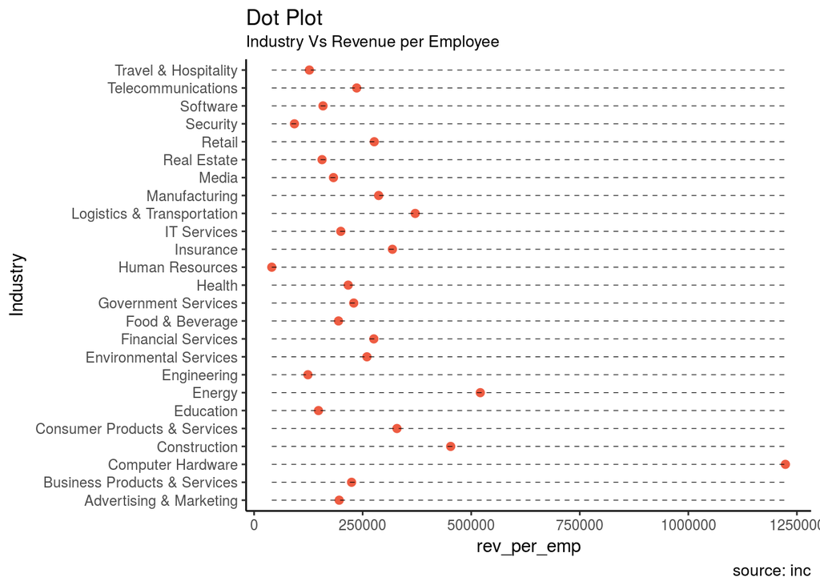

```r
rvn = inc %>% select(Industry, Revenue, Employees)
rvn = rvn[complete.cases(rvn),]
rvn = rvn %>% group_by(Industry) %>% summarize(tot_rev = sum(Revenue), tot_emp = sum(Employees))
rvn$rev_per_emp = rvn$tot_rev / rvn$tot_emp
rvn = rvn[order(rvn$rev_per_emp, decreasing = T),]

# Plot
theme_set(theme_classic())
ggplot(rvn, aes(x=rev_per_emp, y=Industry)) +
  geom_point(col="tomato2", size=2) +   # Draw points
  geom_segment(aes(x=min(rev_per_emp),
                   xend=max(rev_per_emp),
                   y=Industry,
                   yend=Industry),
               linetype="dashed",
               size=0.2) +   # Draw dashed lines
  labs(title="Dot Plot",
       subtitle="Industry Vs Revenue per Employee",
       caption="source: inc")
```